# Ecosystems Assessment: Southern Canadian Shield Ecological Section

Author

Randy Swaty (rswaty@tnc.org)

Published

June 16, 2026

## Introduction

Principle 6 of the [FSC US Forest Stewardship Standard (FSS)](https://us.fsc.org/forest-management/revised-fscr-us-forest-stewardship-standard-v2) aims to maximize positive environmental impacts and minimize adverse environmental impacts of management activities occurring within certified management units. Toward this desired outcome, Criterion 6.5 requires the identification and protection or restoration of native ecosystems that are not already adequately represented and protected in the landscape, defined here as the Ecological Section named above, and in the locator map to the right.

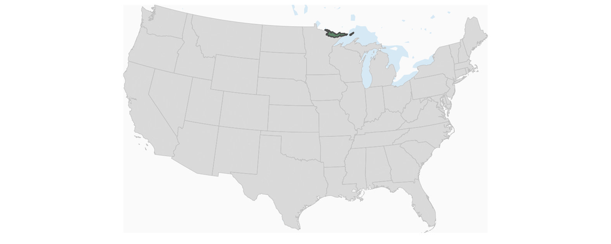

This tool serves to support certificate holders with the requirements of Criterion 6.5 related to Representative Sample Areas (RSAs), but importantly, does not ensure conformance. Additional information gathering and evaluation will most likely be required by certificate holders to ensure conformance with the elements of Criterion 6.5. It is not possible to establish a blanket measurement by which to determine “adequate” protection of all various and complex native ecosystems across the entirety of the conterminous US.

This tool primarily helps with elements of Indicator 6.5.1 and may additionally assist in conformance with Indicators 6.5.2 - 6.5.6. It is deeply aligned with Annex G of the FSC US FSS, which provides guidance for identifying RSAs, as well as guidance for management and activities within RSAs and managing to restore more natural conditions inside or outside of RSAs.

## Native and Existing Vegetation Types

The first step to identifying RSAs (as outlined in Annex G) is to identify native ecosystems that would typically occur in the management unit given current climate and soil conditions. This ﬁrst section helps to identify the native ecosystems that should occur in the landscape given the existing climate and soil conditions (an essential element of Indicator 6.5.1), as well as existing ecosystems that are currently present within the landscape using [LANDFIRE](https://landfire.gov/) data.

Importantly, these assessments only cover the top 10 most prevalent ecosystems. For lesser present ecosystems, we suggest reviewing additional data sources such as State Wildlife Action Plans, [NatureServe](https://www.natureserve.org/), or local conservation initiatives to ensure you have a full understanding of the landscape(s) in which your management unit occurs.

This section also provides tables of the percent of the top 3 ecosystem types that should occur given historic data (native ecosystems) that still remains or is converted to currently present existing ecosystems.

**Note**

We quantified Native Ecosystems using LANDFIRE’s [Biophysical Settings](https://landfire.gov/vegetation/bps) data and Existing Ecosystems using LANDFIRE’s [Existing Vegetation Type-Ecological Systems](https://landfire.gov/vegetation/evt) data. See more about these datasets in “Key Concepts” section below.

Due to evolution of methods and naming conventions the ecosystem names between the Native and Existing ecosystem charts may be different.

### Native Ecosystems

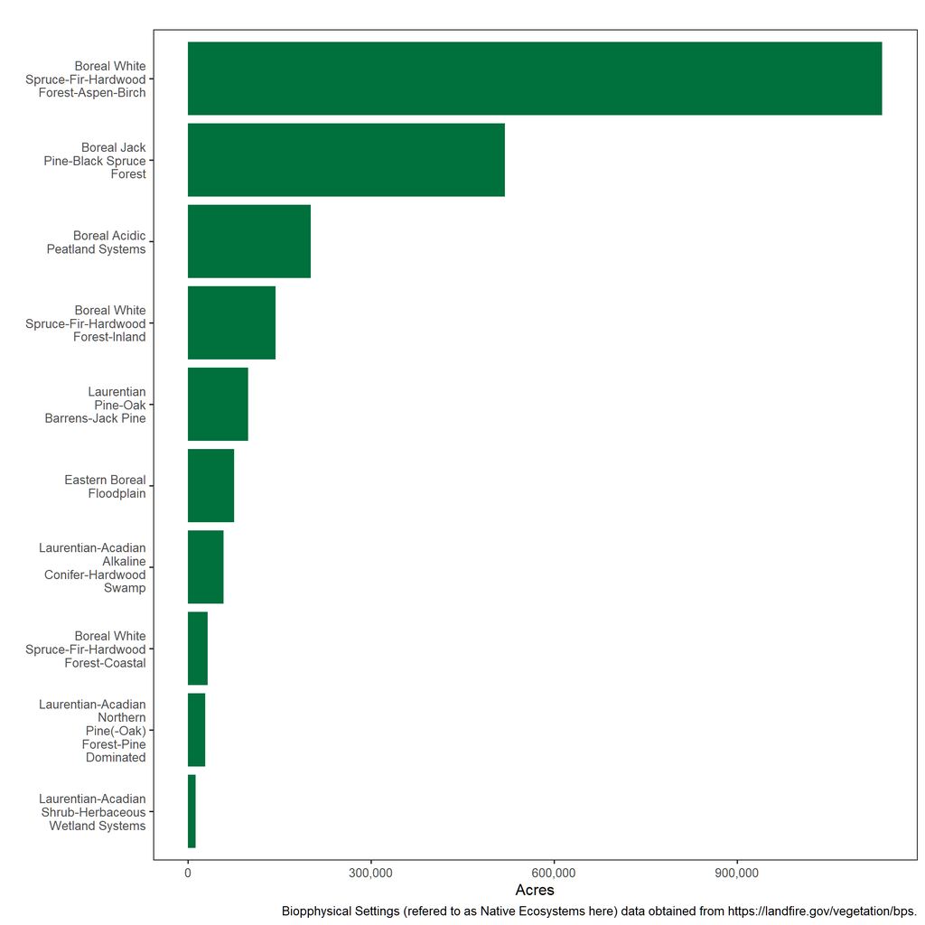

### Existing Ecosystems - 2024

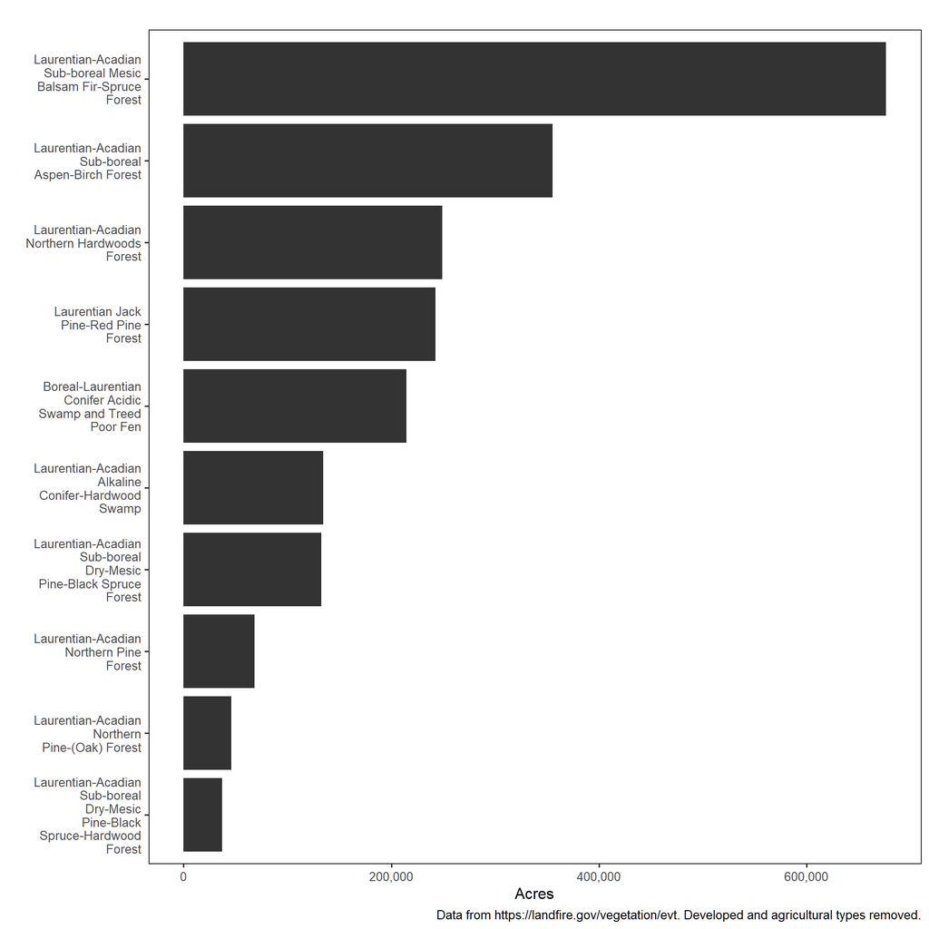

**TipNative and Existing Ecosystems**

For this Ecological System:

- LANDFIRE data shows there were **18** Native Ecosystems (by name, there may be more if counting by regional variants).
- The top 10 Native Ecosystems presented here covered **99%** of the total area.
- As of 2024 LANDFIRE mapped **32** Existing Vegetation Types for this Ecological Section.
- The top 10 Existing Ecosystems cover **93%** of the total area.

### Flow chart: Composition of Existing Ecosystems within the three most prevalent Native Ecosystem footprints

For the charts below we assessed the amounts of each Existing Ecosystem (at a coarse level; includes agricultural and developed types) within each of the top 3 most prevalent Native Ecosystem footprints for this Ecological Section. More specifically, for each 30M x 30M cell (or pixel) we first mapped the Native Ecosystem, then we mapped what that same pixle was in 2024. All of the possible combinations were then tallied up to make the charts below.

**Understanding the Sankey charts:**

- The Native Ecosystem is on the left, coarse-level Existing Ecosystems on the right.
- Hover over the grey horizontal bands to explore how Native Ecosystems have split out to the associated Existing Ecosystems on the current landscape.
- The total current percent of each Existing Ecosystem for this Ecological Section quantified in parentheses.

Boreal White Spruce-Fir-Hardwood Forest-Aspen-Birch (55%)

[interactive chart not shown]

Boreal Jack Pine-Black Spruce Forest (25%)

[interactive chart not shown]

[interactive chart not shown]

### Summary Table of Conversion

| Native Ecosystem | Total Area | Natural Vegetation Remaining | Converted (Agriculture + Developed) | Percent Natural Vegetation Remaining | pct_num |
| --- | --- | --- | --- | --- | --- |
| Boreal White Spruce-Fir-Hardwood Forest-Aspen-Birch | 5,118,473 | 5,016,725 | 101,748 | 98.0% | 0.9801214151173602 |
| Boreal Jack Pine-Black Spruce Forest | 2,336,039 | 2,312,691 | 23,348 | 99.0% | 0.9900053038498073 |
| Boreal Acidic Peatland Systems | 907,221 | 900,509 | 6,712 | 99.3% | 0.9926015821944157 |
| Boreal White Spruce-Fir-Hardwood Forest-Inland | 645,927 | 639,847 | 6,080 | 99.1% | 0.9905871716153682 |
| Laurentian Pine-Oak Barrens-Jack Pine | 445,957 | 442,384 | 3,573 | 99.2% | 0.9919880167818871 |
| Eastern Boreal Floodplain | 341,387 | 338,135 | 3,252 | 99.0% | 0.9904741539660268 |
| Laurentian-Acadian Alkaline Conifer-Hardwood Swamp | 264,893 | 262,256 | 2,637 | 99.0% | 0.9900450370526968 |
| Boreal White Spruce-Fir-Hardwood Forest-Coastal | 146,519 | 144,028 | 2,491 | 98.3% | 0.9829987919655472 |
| Laurentian-Acadian Northern Pine(-Oak) Forest-Pine Dominated | 129,738 | 126,208 | 3,530 | 97.3% | 0.972791317886818 |
| Laurentian-Acadian Shrub-Herbaceous Wetland Systems | 57,192 | 56,574 | 618 | 98.9% | 0.989194292908099 |

**Note**

**Consideration:** Before moving on to the next section think through which ecosystems have been most impacted by conversion. If a system has largely been converted to agricultural and developed land uses AND it has low levels of protection below it may be worth additional consideration.

## GAP Status

The second step to identifying RSAs (as outlined in Annex G) is to assess the adequacy of representation and protection of the identified native ecosystems within the landscape. This next section provides the first step to making this assessment by showing percent of each of the top 10 ecosystems (those listed above) that is protected in Gap Status 1, 2, or 3 lands. It does not evaluate “adequate” vs “inadequate” levels of protection and representation, which will be unique to each identiﬁed ecosystem type and its distinct qualities.

**The GAP status codes are defined as (copied from https://www.usgs.gov/programs/gap-analysis-project/gap-status-code-frequently-asked-questions-faq):**

**Gap Status 1:** An area having permanent protection from conversion of natural land cover and a mandated management plan in operation to maintain a natural state within which disturbance events (of natural type, frequency, intensity, and legacy) are allowed to proceed without interference or are mimicked through management.

**Gap Status 2:** An area having permanent protection from conversion of natural land cover and a mandated management plan in operation to maintain a primarily natural state, but which may receive uses or management practices that degrade the quality of existing natural communities, including suppression of natural disturbance.

**Gap Status 3:** An area having permanent protection from conversion of natural land cover for the majority of the area, but subject to extractive uses of either a broad, low intensity type (for example, logging, Off-Highway Vehicle recreation) or localized intense type (for example, mining). It also confers protection to federally listed endangered and threatened species throughout the area.

**GAP status 4 not shown in chart below. Chart is interactive. Hover over bars to get more information.**

[interactive chart not shown]

**Tip**

**Protection Status**

- The lowest observed protection level is **72%**.
- Ecosystems with the least protection include: **Laurentian-Acadian Sub-boreal Aspen-Birch Forest (72%); Laurentian-Acadian Northern Hardwoods Forest (73%); Laurentian-Acadian Alkaline Conifer-Hardwood Swamp (76%)**.
- The lowest level of strict protection (GAP Status 1) is **28.0%**, with the least represented ecosystems including: **Laurentian-Acadian Sub-boreal Aspen-Birch Forest (28.0%); Laurentian-Acadian Alkaline Conifer-Hardwood Swamp (34.3%); Laurentian-Acadian Northern Hardwoods Forest (38.1%)**.

## Next Steps

If the result of the assessment conducted using the information above combined with additional research and justification on the part of the certificate holder shows that all native ecosystems are adequately represented or protected in the landscape, then there is no need to establish RSAs within the management unit. If the results of the assessment find that there are native ecosystems that are not adequately represented or protected within the landscape, viable examples of these ecosystems will need to be designated as Representative Sample Areas within the management unit. If there are no viable examples, degraded examples that could be restored are designated as RSAs and are managed to restore to more natural conditions.

### Exploration of Successional Classes and Historical Disturbance Amounts for top Native Ecosystems

Understanding successional class data for the native ecosystems in your landscape can help provide a more in-depth view into levels of representation and protection, This data may be especially helpful if the assessments conducted above show that there is a need to establish RSAs within your management unit. Designating areas of native ecosystems within your management unit that represent underrepresented successional classes is encouraged. The table below provides greater insight into historic vs current succession class amounts for the top native ecosystems in your landscape.

### Reference and Current Succession Class Amounts for top Native Ecosystems

We quantified Native Ecosystems using LANDFIRE’s [Biophysical Settings](https://landfire.gov/vegetation/bps) spatial data, “reference” succession class amounts from LANDFIRE’s [Biophysical Settings Models](https://landfire.gov/vegetation/bps-models), and current amounts of each succession class using LANDFIRE’s (Succession Class)[https://landfire.gov/vegetation/sclass]spatial data. See more about these datasets in “Key Concepts” section below.

**About the charts that follow:**

- We selected the top 10 Native Ecosystems by their unique numerical code for the charts below. Most Native Ecosystems have ‘variants’ representing different reference conditions (e.g., different successional stages and amounts). Therefore there may be multiple charts per BpS name, and each Native Ecosystem in the ‘Native Ecosystems’ chart above may not have a chart below.
- Native Ecosystem (i.e., LANDFIRE Biophysical Settings) descriptions and succession class definitions presented at bottom of report)
- Because the succession classes are custom for each ecosystem the classes are labeled simply as A-E, plus:
  - UN for “Uncharacteristic Native”, or situations where the vegetation is native, but the structure (i.e., canopy cover and height) currently present was not defined as reference.
  - UE for “Uncharacteristic Exotic” For descriptions of the classes see table below (and documents as well).

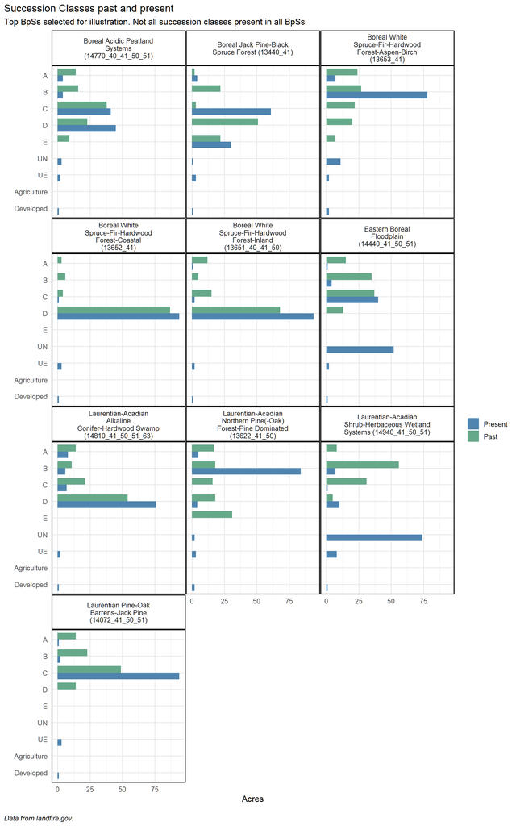

### Annual Historical Disturbance Amounts for top Native Ecosystems

In order to estimate historical amounts of succession classes, LANDFIRE used state and transition modeling with specifics captured in the (Biophysical Settings Models and Descriptions)[https://landfire.gov/vegetation/bps-models]. The transitions in this context are natural disturbances. By multiplying the modeled annual probability by the mapped amount of an BpS, we can estimate annual disturbance amounts.

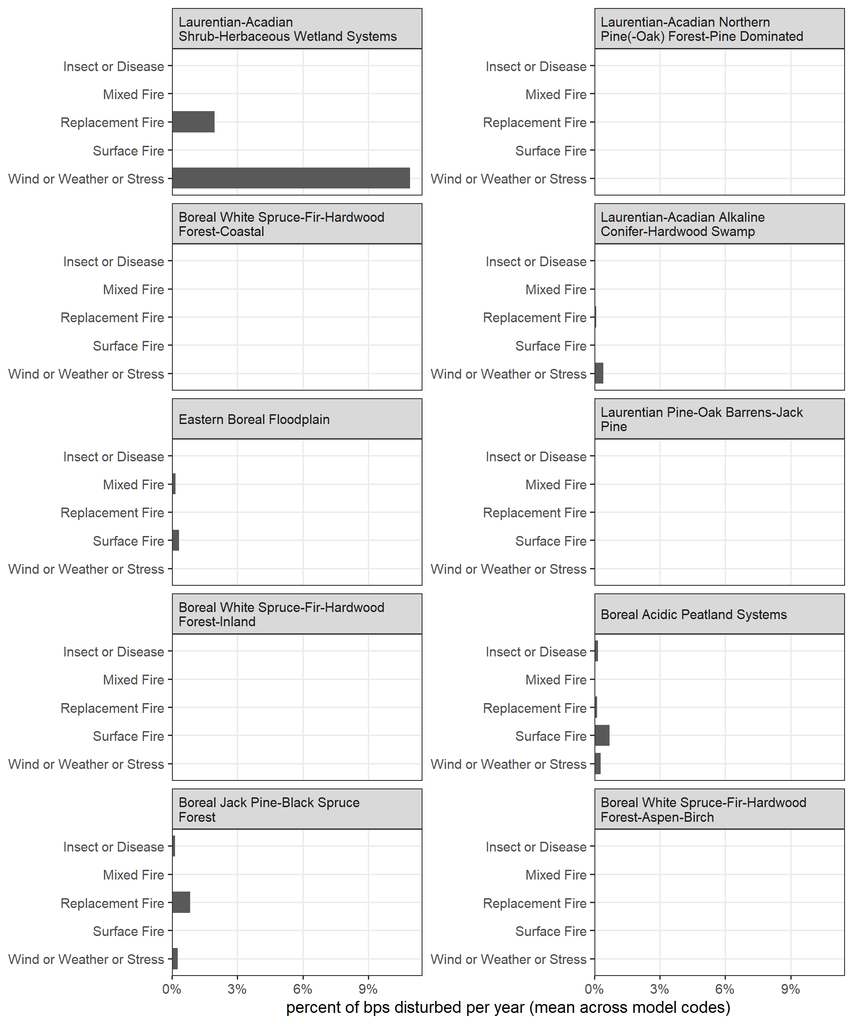

## Key Concepts about the input data from LANDFIRE:

In order to better understand the the quantity of historical ecosystems, their protection status, ecological condition and natural disturbance regimes at a landscape scale, we summarized LANDFIRE and GAP data to Ecological Sections. These summaries are coarse, aimed at setting context and setting the stage for structured analysis of more local management areas.

## Native Ecosystem Descriptions and Succession Class Definitions

To better understand ‘reference’ conditions for the Native Ecosystems of the US, the LANDFIRE program developed descriptions plus accompanying state-and-transition models that depict how these systems ‘looked and functioned’ with natural disturbance regimes. Below you can download the descriptions for the dominant Native Ecosystems and explore the succession class descriptions in a table.

LANDFIRE developed and delivers this information by Map Zone. If an ecosystem crosses multiple Map Zones there may be multiple ‘variants’. In the table of links to the descriptions you will see “Model Codes”, which represent an unique 5 digit code for the system followed by a list of Map Zones that description applies to.

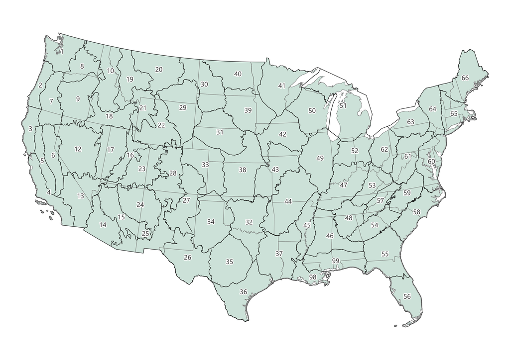

LANDFIRE Map Zones for the lower 48 states

| Native Ecosystem | Model Code | Document |
| --- | --- | --- |
| Boreal Jack Pine-Black Spruce Forest | 13440_41 | Boreal Jack Pine-Black Spruce Forest (13440_41) |
| Laurentian-Acadian Northern Pine(-Oak) Forest - Pine Dominated | 13622_41_50 | Laurentian-Acadian Northern Pine(-Oak) Forest - Pine Dominated (13622_41_50) |
| Boreal White Spruce-Fir-Hardwood Forest - Inland | 13651_40_41_50 | Boreal White Spruce-Fir-Hardwood Forest - Inland (13651_40_41_50) |
| Boreal White Spruce-Fir-Hardwood Forest - Coastal | 13652_41 | Boreal White Spruce-Fir-Hardwood Forest - Coastal (13652_41) |
| Boreal White Spruce-Fir-Hardwood Forest - Aspen-Birch | 13653_41 | Boreal White Spruce-Fir-Hardwood Forest - Aspen-Birch (13653_41) |
| Laurentian Pine-Oak Barrens - Jack Pine | 14072_41_50_51 | Laurentian Pine-Oak Barrens - Jack Pine (14072_41_50_51) |
| Eastern Boreal Floodplain | 14440_41_50_51 | Eastern Boreal Floodplain (14440_41_50_51) |
| Boreal Acidic Peatland Systems | 14770_40_41_50_51 | Boreal Acidic Peatland Systems (14770_40_41_50_51) |
| Laurentian-Acadian Alkaline Conifer-Hardwood Swamp | 14810_41_50_51_63 | Laurentian-Acadian Alkaline Conifer-Hardwood Swamp (14810_41_50_51_63) |
| Laurentian-Acadian Shrub-Herbaceous Wetland Systems | 14940_41_50_51 | Laurentian-Acadian Shrub-Herbaceous Wetland Systems (14940_41_50_51) |

As noted above each Native Ecosystem has up to 5 succession classes, and each one has unique descriptions and mapping rules. Those descriptions and mapping rules for the Native Ecosystems presented in the Succession Class Chart are presented below.

| Native Ecosystem Name | BpS Model | Class label | Short description | Full description | sort_id |
| --- | --- | --- | --- | --- | --- |
| Boreal Jack Pine-Black Spruce Forest | 13440_41 | A | Early1:ALL | Seedling fir, spruce , and cedar because of windthrow in the other classes. A replacement fire in this state will result in seedling jack pine (Box B). Frelich reports a fire return interval of 100yrs… | Early1:ALL |
| Boreal Jack Pine-Black Spruce Forest | 13440_41 | B | Early2:CLS | Jack Pines Canopy cover is patchy. Understory is feathermoss. | Early2:CLS |
| Boreal Jack Pine-Black Spruce Forest | 13440_41 | C | Mid1:CLS | Sapling - to - pole spru ce, fir , and cedar . | Mid1:CLS |
| Boreal Jack Pine-Black Spruce Forest | 13440_41 | D | Mid2:CLS | Pole t o large jack pine . | Mid2:CLS |
| Boreal Jack Pine-Black Spruce Forest | 13440_41 | E | Late1:CLS | Multi-aged fir, spruce , and cedar stands. | Late1:CLS |
| Laurentian-Acadian Northern Pine(-Oak) Forest - Pine Dominated | 13622_41_50 | A | Early1:ALL | This class is a regeneration phase following a stand - replacing fire or wind disturbance. A nearby seed source is assumed , which regenerates the site to red/white pine. It consists mainly of red pin… | Early1:ALL |
| Laurentian-Acadian Northern Pine(-Oak) Forest - Pine Dominated | 13622_41_50 | B | Mid1:CLS | This stage also includes scattered paper birch, jack pine, balsam fir, red maple , and occasionally oak. In this stage , red and white pine dominate and overtop the hardwoods and fir. Black and white … | Mid1:CLS |
| Laurentian-Acadian Northern Pine(-Oak) Forest - Pine Dominated | 13622_41_50 | C | Mid2:CLS | Without fire , balsam fir increases in density , as do birch and maple , and form a sporadic midstory. What aspen was present initially begins to drop out due to windthrow. Red and white pine continue… | Mid2:CLS |
| Laurentian-Acadian Northern Pine(-Oak) Forest - Pine Dominated | 13622_41_50 | D | Late1:CLS | Some overstory pines begin to succumb to windthrow . The understory of balsam fir and/or shrubs and hardwoods becomes quite dense. Openings in the canopy are filled with balsam, spruce , and birch. No… | Late1:CLS |
| Laurentian-Acadian Northern Pine(-Oak) Forest - Pine Dominated | 13622_41_50 | E | Late2:CLS | Many overstory pines succumb to windthrow. Windthrow, modeled with a probability of occurring every 1 , 000yrs, could maintain the system in this class or take it to C lass B or A depending on advance… | Late2:CLS |

[output cut: 34 more lines]